# Regression Project

### Problem Statement

In foods, CODA (close of day availability) is one of the most important performance metrics. There are many departments and functions who are involved in the responsibility of the outcome of CODA. Previously there was no measure for the different functions to understand how their actions impacted CODA. A new measure was introduced to the business called Standards. The idea is, given all other variables stay constant the standard is the value supply chain must achieve. CODA previously was just measured against products performance last year, if a product has no history, it was viewed up against a similar product. Standards uses a more comprehensive process to calculate the target value. A couple steps used in the process are the following:

- Previous four weeks’ worth of data on a rolling basis.
- The use of data from similar products also.

Using regression, it is hoped the model can learn the standards value and then recreate them. My initial expectation is that categories with a more constant CODA value like “Confectionery”, “Beers & Spirits” and “Groceries” will have a more accurate recreated standards value. Categories with a less consistent CODA value will have a less accurate recreated standards value such as “Fruit”, “Food on the move” and “Poultry”.

##### Hypothesis

Null hypothesis:

There is no significant difference between the original standards and the recreated standards.

Alternative hypothesis:

There is a significant difference between the original standards and the recreated standards.

The significant level will be set at 0.05

### Overview

The initial plan for the project is as follows:

1. Source the data
2. Explore & clean the data
3. Prepare the data for analysis
4. Analyse the data
5. Evaluate the model
6. Improve the model

### Source the data

The data was sourced from a report called Horizon which was created by the food analytics team. The data is at product level but aggregated to different time periods. For a better CODA value, the last four weeks aggregation was selected. Initial thoughts about potential issues:

- Since the last four weeks is used in calculating the original standards, could this result in perfect regression results.
- As standards are calculated at day level, could an aggregation of the last four weeks cause the results to be less accurate as there would be 28 less data points for each product/metric combination.

### Explore & clean the data

Initially the idea was to explore, clean and then prepare the data but due to issue while exploring It was decided to merge the exploring and the cleaning process into one.

```python
# Import necessary packages for data exploration and analysis
import pandas as pd
import matplotlib.pyplot as plt
import numpy as np
from sklearn import datasets, linear_model
from sklearn.metrics import mean_squared_error, r2_score
from sklearn.model_selection import train_test_split
import seaborn as sns
import statsmodels.formula.api as smf
from sklearn.metrics import mean_squared_error
from math import sqrt
import statsmodels.api as sm
from statsmodels.graphics.api import abline_plot
import warnings
```

```python
# Load the data from a csv file into a data frame
dataset = pd.read_csv('Horizon_Stands.csv')
```

```python
# Gather basic information about the dataset
print(f"Rows: {dataset.shape[0]}\nColumns: {dataset.shape[1]}")
```

```
Rows: 4137
Columns: 16
```

```python
# Look at the first 5 rows of data
dataset.head(5)
```

|  | SUPER_CLUSTER | CLUSTER | CATEGORY_NAME | SUPER_PRODUCT_CATEGORY_NAME | UPC | TGT | CODA_STAND | CODA | WASTE_STAND | WASTE | DEMAND | FORECAST | STOCKING_POINTS | LOST_SALES | WASTE_UNITS | SALES_UNITS |
| --- | --- | --- | --- | --- | --- | --- | --- | --- | --- | --- | --- | --- | --- | --- | --- | --- |
| 0 | Convenience | Eat Out of Home | Direct Mag Subscriptions | Magazine Subs | 655774 | 0.86 | NaN | NaN | NaN | NaN | NaN | NaN | 0.0 | NaN | NaN | NaN |
| 1 | Convenience | Eat Out of Home | Direct Mag Subscriptions | Magazine Subs | 655781 | 0.86 | NaN | NaN | NaN | NaN | NaN | NaN | 0.0 | NaN | NaN | NaN |
| 2 | Convenience | Eat Out of Home | Direct Mag Subscriptions | Magazine Subs | 655798 | 0.86 | NaN | NaN | NaN | NaN | NaN | NaN | 0.0 | NaN | NaN | NaN |
| 3 | Convenience | Eat Out of Home | Direct Mag Subscriptions | Magazine Subs | 655835 | 0.86 | NaN | NaN | NaN | NaN | NaN | NaN | 0.0 | NaN | NaN | NaN |
| 4 | Convenience | Eat Out of Home | Direct Mag Subscriptions | Magazine Subs | 655873 | 0.86 | NaN | NaN | NaN | NaN | NaN | NaN | 0.0 | NaN | NaN | NaN |

Data was loaded successfully and basic information about the data has now been established. We can clearly see a lot of NaN rows which means the data set will need to be cleaned.

The next step is to look at the selected independent variable the model will be predicting.

```
array([[<matplotlib.axes._subplots.AxesSubplot object at 0x0000000020AD5898>]],
      dtype=object)
```

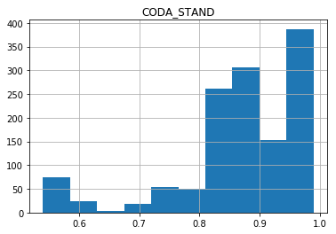

```python
# Create a histogram of the CODA_STAND variable
dataset.hist(column="CODA_STAND")
```

```python
# Gather basic statistical information about the CODA_STAND variable
dataset["CODA_STAND"].describe()
```

```
count    1329.000000
mean        0.868721
std         0.114711
min         0.540000
25%         0.840000
50%         0.880000
75%         0.990000
max         0.990000
Name: CODA_STAND, dtype: float64
```

Looking at the description of the variable we can see the following:

- Count is only 1329 compared to 4137 rows which means we have a lot of NaN in our data set.
- From the 25% percentile point and above the data is above 0.8 which matches our histogram.
- The mean 0.86 which again matches our histogram.

```python
# Get the accurate counts for each variable
dataset.count()
```

```
SUPER_CLUSTER                  4137
CLUSTER                        4137
CATEGORY_NAME                  4137
SUPER_PRODUCT_CATEGORY_NAME    4137
UPC                            4137
TGT                            4137
CODA_STAND                     1329
CODA                           1330
WASTE_STAND                    1266
WASTE                          1436
DEMAND                         1727
FORECAST                       1727
STOCKING_POINTS                2492
LOST_SALES                     2582
WASTE_UNITS                    1458
SALES_UNITS                    2582
dtype: int64
```

Clearly, we can see different count values for different columns, firstly we will clear CODA_STAND as this is our dependant variable and need this column as clean as possible.

```python
# Drop NaN values by keeping all non null values in CODA_STAND column
data = dataset[dataset.CODA_STAND.notnull()]
# Get the accurate counts for each variable
data.count()
```

```
SUPER_CLUSTER                  1329
CLUSTER                        1329
CATEGORY_NAME                  1329
SUPER_PRODUCT_CATEGORY_NAME    1329
UPC                            1329
TGT                            1329
CODA_STAND                     1329
CODA                           1268
WASTE_STAND                    1266
WASTE                          1225
DEMAND                         1327
FORECAST                       1327
STOCKING_POINTS                1329
LOST_SALES                     1321
WASTE_UNITS                    1227
SALES_UNITS                    1321
dtype: int64
```

Now we have cleared the dependent variable column lets clean the rest of the independent variables so that we always have a corresponding value for CODA_STAND in each of the other columns.

```python
# Drop NaN values by keeping all non null values
df = data[data.CODA.notnull()]
# Get the accurate counts for each variable
df.count()
```

```
SUPER_CLUSTER                  1268
CLUSTER                        1268
CATEGORY_NAME                  1268
SUPER_PRODUCT_CATEGORY_NAME    1268
UPC                            1268
TGT                            1268
CODA_STAND                     1268
CODA                           1268
WASTE_STAND                    1245
WASTE                          1204
DEMAND                         1267
FORECAST                       1267
STOCKING_POINTS                1268
LOST_SALES                     1267
WASTE_UNITS                    1204
SALES_UNITS                    1267
dtype: int64
```

```python
# Drop NaN values by keeping all non null values
df2 = df[df.WASTE_STAND.notnull()]
# Get the accurate counts for each variable
df2.count()
```

```
SUPER_CLUSTER                  1245
CLUSTER                        1245
CATEGORY_NAME                  1245
SUPER_PRODUCT_CATEGORY_NAME    1245
UPC                            1245
TGT                            1245
CODA_STAND                     1245
CODA                           1245
WASTE_STAND                    1245
WASTE                          1204
DEMAND                         1245
FORECAST                       1245
STOCKING_POINTS                1245
LOST_SALES                     1245
WASTE_UNITS                    1204
SALES_UNITS                    1245
dtype: int64
```

```python
# Drop NaN values by keeping all non null values
df3 = df2[df2.WASTE.notnull()]
# Get the accurate counts for each variable
df3.count()
```

```
SUPER_CLUSTER                  1204
CLUSTER                        1204
CATEGORY_NAME                  1204
SUPER_PRODUCT_CATEGORY_NAME    1204
UPC                            1204
TGT                            1204
CODA_STAND                     1204
CODA                           1204
WASTE_STAND                    1204
WASTE                          1204
DEMAND                         1204
FORECAST                       1204
STOCKING_POINTS                1204
LOST_SALES                     1204
WASTE_UNITS                    1204
SALES_UNITS                    1204
dtype: int64
```

Now we have a clean data set where we have a value for every row in every column.

```python
# Check the data frame information and types
df3.info()
```

```
<class 'pandas.core.frame.DataFrame'>
Int64Index: 1204 entries, 22 to 4133
Data columns (total 16 columns):
SUPER_CLUSTER                  1204 non-null object
CLUSTER                        1204 non-null object
CATEGORY_NAME                  1204 non-null object
SUPER_PRODUCT_CATEGORY_NAME    1204 non-null object
UPC                            1204 non-null int64
TGT                            1204 non-null float64
CODA_STAND                     1204 non-null float64
CODA                           1204 non-null float64
WASTE_STAND                    1204 non-null float64
WASTE                          1204 non-null float64
DEMAND                         1204 non-null float64
FORECAST                       1204 non-null float64
STOCKING_POINTS                1204 non-null float64
LOST_SALES                     1204 non-null float64
WASTE_UNITS                    1204 non-null float64
SALES_UNITS                    1204 non-null float64
dtypes: float64(11), int64(1), object(4)
memory usage: 199.9+ KB
```

Looking at the data types UPC needs to be changed to an object so the model doesn’t mistake it for a numerical value. The rest of the variables are all float64 which means they are continuous numerical values which is perfect for regression analysis.

```python
# Change data type of specific column
df3['UPC'] = df3.UPC.astype(object)
```

[output not shown]

```python
# Check the data frame information and types
df3.info()
```

```
<class 'pandas.core.frame.DataFrame'>
Int64Index: 1204 entries, 22 to 4133
Data columns (total 16 columns):
SUPER_CLUSTER                  1204 non-null object
CLUSTER                        1204 non-null object
CATEGORY_NAME                  1204 non-null object
SUPER_PRODUCT_CATEGORY_NAME    1204 non-null object
UPC                            1204 non-null object
TGT                            1204 non-null float64
CODA_STAND                     1204 non-null float64
CODA                           1204 non-null float64
WASTE_STAND                    1204 non-null float64
WASTE                          1204 non-null float64
DEMAND                         1204 non-null float64
FORECAST                       1204 non-null float64
STOCKING_POINTS                1204 non-null float64
LOST_SALES                     1204 non-null float64
WASTE_UNITS                    1204 non-null float64
SALES_UNITS                    1204 non-null float64
dtypes: float64(11), object(5)
memory usage: 199.9+ KB
```

```python
# Pivot the data to count values in each cluster
df3['CLUSTER'].value_counts()
```

```
Meals Desserts & Frozen    843
Eat Out of Home            361
Name: CLUSTER, dtype: int64
```

```python
# Pivot the data to count values in each category
df3['CATEGORY_NAME'].value_counts()
```

```
Food onthe Move           361
Frozen                    207
Global Meal Solutions     189
Traditional Meal Sol      152
Desserts                  138
Healthy Meal Solutions    101
Prepared Veg               56
Name: CATEGORY_NAME, dtype: int64
```

After further exploring the count of the data we can see that we only have two clusters and 7 categories. It will be interesting to understand why there is so much missing data given the data is aggregated from the last four weeks.

Now let’s drop all categorical columns from the data frame.

```python
# drop() function to drop columns not needed in the model
dataset2 = df3.drop(['SUPER_CLUSTER','CLUSTER','CATEGORY_NAME','UPC','SUPER_PRODUCT_CATEGORY_NAME'], axis=1)
```

Now let’s look at visualising the potential correlations between all our variables. Pairplot from sns, can give us a comprehensive view of the data. Maybe we can see which variable can accurately predict the CODA_STAND.

From the pair plot we can see some interesting correlations shown. The diagonal chats from top left are different as they show the distribution for each column instead of plotting the correlation against itself. From the pair plot we can clearly see the most interesting correlation is in fact between CODA_STAND and CODA. Let’s take a closer look at this relationship.

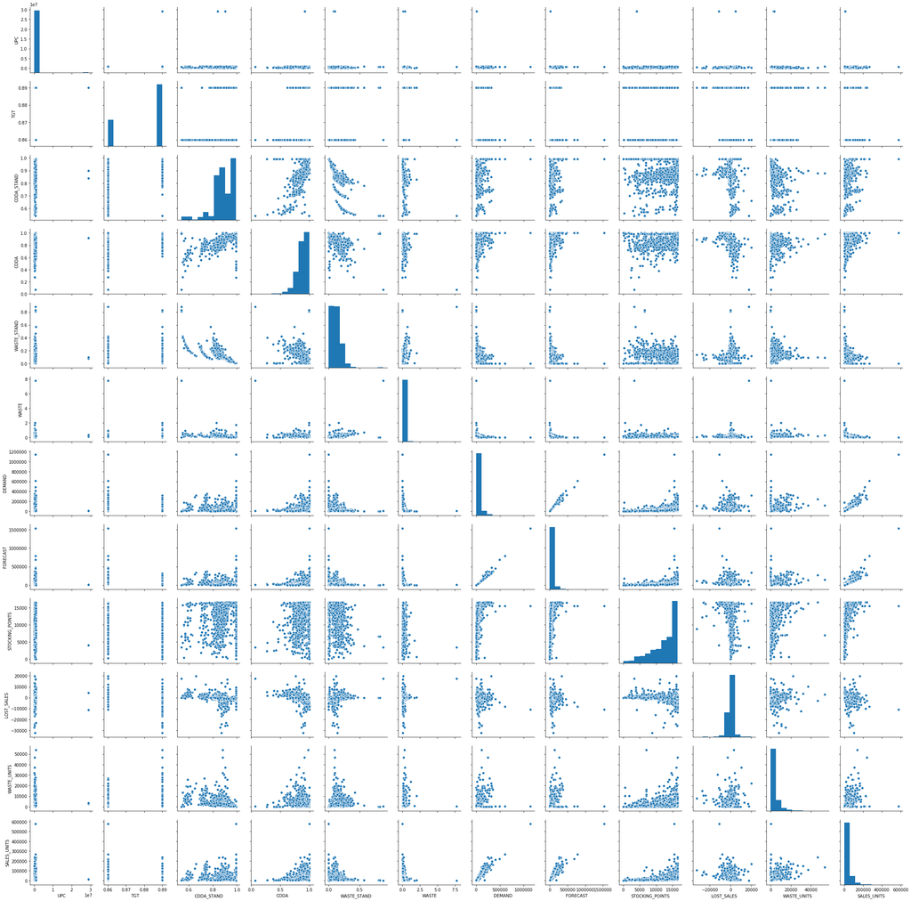

```python
# Create a pairplot
sns.pairplot(df3)
```

Now let’s look at the correlation coefficient between the two variables.

```python
# Evaluate the correlation coefficient between CODA_STAND and CODA.
dataset2['CODA_STAND'].corr(dataset2['CODA'])
```

```
0.7316676251720766
```

```python
# Evaluate the correlation coefficient between CODA and CODA_STAND.
dataset2['CODA'].corr(dataset2['CODA_STAND'])
```

```
0.7316676251720765
```

What we notice from the correlation outcome:

- There is no difference between the correlation coefficient of CODA_STAND and CODA, and the correlation coefficient of CODA and CODA_STAND.
- The correlation coefficient is a positive number, which indicates that an increase in CODA will reflect an increase in CODA_STAND.
- The correlation coefficient is 0.7316676251720766 given that the range is between 0 and 1, this is considered a strong correlation.

Lets take a look at all the correlation coefficients for all the variables to get a better numerical understanding.

```python
# Display the same information numerically instead of visually
dataset2.corr()
```

|  | TGT | CODA_STAND | CODA | WASTE_STAND | WASTE | DEMAND | FORECAST | STOCKING_POINTS | LOST_SALES | WASTE_UNITS | SALES_UNITS |
| --- | --- | --- | --- | --- | --- | --- | --- | --- | --- | --- | --- |
| TGT | 1.000000 | 0.230368 | 0.173975 | 0.019583 | -0.041312 | -0.303097 | -0.301831 | 0.048956 | -0.255674 | -0.085444 | -0.133038 |
| CODA_STAND | 0.230368 | 1.000000 | 0.731668 | -0.802114 | -0.388514 | -0.104001 | -0.071400 | 0.150134 | -0.275919 | -0.475261 | -0.068409 |
| CODA | 0.173975 | 0.731668 | 1.000000 | -0.613291 | -0.446989 | 0.075914 | 0.087708 | 0.255067 | -0.379266 | -0.257775 | 0.115466 |
| WASTE_STAND | 0.019583 | -0.802114 | -0.613291 | 1.000000 | 0.512554 | -0.085051 | -0.096648 | -0.193014 | 0.192879 | 0.282447 | -0.095483 |
| WASTE | -0.041312 | -0.388514 | -0.446989 | 0.512554 | 1.000000 | -0.085021 | -0.079585 | -0.217123 | 0.202268 | 0.219136 | -0.102538 |
| DEMAND | -0.303097 | -0.104001 | 0.075914 | -0.085051 | -0.085021 | 1.000000 | 0.987199 | 0.364423 | -0.126668 | 0.387962 | 0.933859 |
| FORECAST | -0.301831 | -0.071400 | 0.087708 | -0.096648 | -0.079585 | 0.987199 | 1.000000 | 0.325482 | -0.132335 | 0.336000 | 0.904351 |
| STOCKING_POINTS | 0.048956 | 0.150134 | 0.255067 | -0.193014 | -0.217123 | 0.364423 | 0.325482 | 1.000000 | -0.225127 | 0.209012 | 0.445370 |
| LOST_SALES | -0.255674 | -0.275919 | -0.379266 | 0.192879 | 0.202268 | -0.126668 | -0.132335 | -0.225127 | 1.000000 | 0.048825 | -0.212737 |
| WASTE_UNITS | -0.085444 | -0.475261 | -0.257775 | 0.282447 | 0.219136 | 0.387962 | 0.336000 | 0.209012 | 0.048825 | 1.000000 | 0.469527 |
| SALES_UNITS | -0.133038 | -0.068409 | 0.115466 | -0.095483 | -0.102538 | 0.933859 | 0.904351 | 0.445370 | -0.212737 | 0.469527 | 1.000000 |

Now let’s visualise this table for a better view.

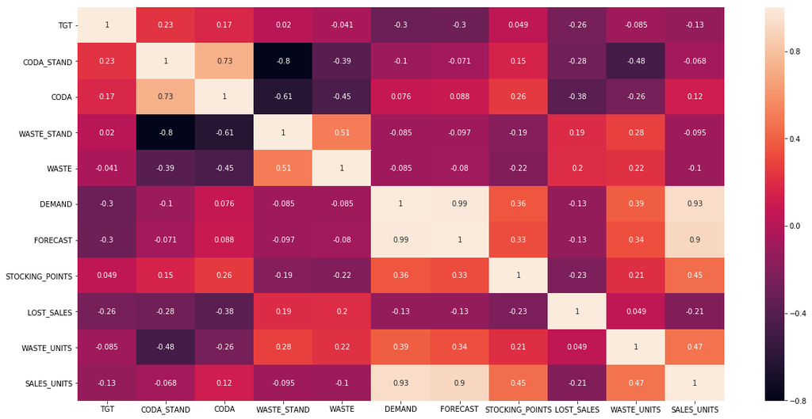

```python
# Ensure the plot displays in a large enough size to be readable
plt.figure(figsize=(20,10))
# Create an annotated heatmap of the correlations
sns.heatmap(dataset2.corr(), annot=True)
# The "annot" parameter tells the plot to display labels
```

The colour matrix is a great way to easily spot correlations. The lighter the colour the closer the value is to 1 and the darker the colour the closer the value is to -1.

As we want to predict CODA_STAND, let's look more closely at CODA_STANDS relationship to CODA.

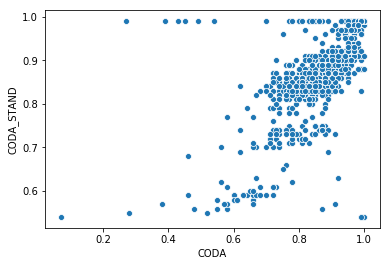

```python
# Plot CODA against CODA_STAND
r = sns.scatterplot(x='CODA', y='CODA_STAND', data=dataset2)
```

We can see a positive correlation, but some what a strong one, as some data points are quite spread out. CODA_STAND is positively correlated with CODA.

[output not shown]

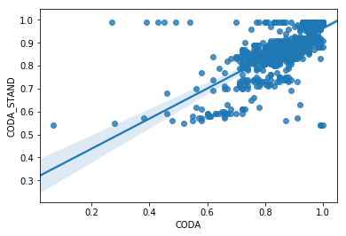

```python
# Plot data and a linear regression model fit
e = sns.regplot(x='CODA', y='CODA_STAND', data = dataset2)
```

The line of best fit matches the shape of the data with most of the data points clustered around the line except for a few data points that don’t seem to follow the pattern.

[output not shown]

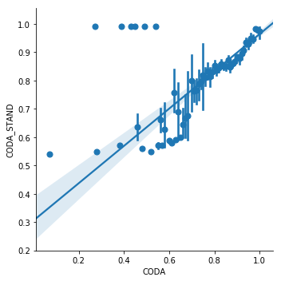

```python
# Plot data and regression model fits across a FacetGrid
g = sns.lmplot(x='CODA', y='CODA_STAND', data = dataset2, x_estimator=np.mean)
```

The plot above shows an estimate of central tendency along with a confidence interval and we can see that the data follows the line of best fit.

[output not shown]

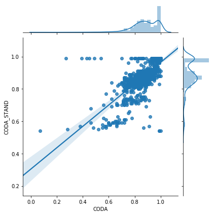

```python
# Draw a plot of two variables with bivariate and univariate graphs
n = sns.jointplot(x='CODA', y='CODA_STAND', data = dataset2, kind="reg")
```

The graph above also includes the distribution of the data which is quite useful to see with the line of best fit as we can see more clearly the volume of data at each point. Most of the data is clustered around the line of best fit.